# Bank Marketing

## Analysis of Marketing from the Banco de Portugal

The data used in this project comes from a marketing campaign by the Banco de Portugal to encourage customers to subscribe to a term deposit. It includes attributes about the customer, how the marketing was conducted, relevant economic indicators, and whether the offer was accepted or declined.

```python
import pandas as pd
import statsmodels.formula.api as smf
import statsmodels.api as sm
import matplotlib.pyplot as plt
import seaborn as sns
import numpy as np
from sklearn.metrics import confusion_matrix
from sklearn.neighbors import KNeighborsClassifier
from sklearn.model_selection import train_test_split
from sklearn.tree import DecisionTreeClassifier
```

```python
df= pd.read_excel('C:\\Users\\Woyte\\Desktop\\Bank.xlsx')
```

```python
df.head()
```

|  | age | job | marital | education | default | housing | loan | contact | month | day_of_week | ... | campaign | pdays | previous | poutcome | emp.var.rate | cons.price.idx | cons.conf.idx | euribor3m | nr.employed | y |
| --- | --- | --- | --- | --- | --- | --- | --- | --- | --- | --- | --- | --- | --- | --- | --- | --- | --- | --- | --- | --- | --- |
| 0 | 56 | housemaid | married | basic.4y | no | no | no | telephone | may | mon | ... | 1 | 999 | 0 | nonexistent | 1.1 | 93.994 | -36.4 | 4.857 | 5191.0 | no |
| 1 | 57 | services | married | high.school | unknown | no | no | telephone | may | mon | ... | 1 | 999 | 0 | nonexistent | 1.1 | 93.994 | -36.4 | 4.857 | 5191.0 | no |
| 2 | 37 | services | married | high.school | no | yes | no | telephone | may | mon | ... | 1 | 999 | 0 | nonexistent | 1.1 | 93.994 | -36.4 | 4.857 | 5191.0 | no |
| 3 | 40 | admin. | married | basic.6y | no | no | no | telephone | may | mon | ... | 1 | 999 | 0 | nonexistent | 1.1 | 93.994 | -36.4 | 4.857 | 5191.0 | no |
| 4 | 56 | services | married | high.school | no | no | yes | telephone | may | mon | ... | 1 | 999 | 0 | nonexistent | 1.1 | 93.994 | -36.4 | 4.857 | 5191.0 | no |

5 rows × 21 columns

```python
df = df[df != 'unknown']
df.dropna(inplace=True)
#Deleting cells with unknown information from data
```

```python
dummy=pd.get_dummies(df['default'])
dummy2=pd.get_dummies(df['housing'])
dummy3=pd.get_dummies(df['loan'])
dummy4=pd.get_dummies(df['y'])
df= pd.concat([df, dummy], axis=1)
df= df.drop('no',axis=1)
df['Ydefault']=df['yes']
df=df.drop('yes', axis=1)
df= pd.concat([df, dummy2], axis=1)
df= df.drop('no',axis=1)
df['Yhousing']=df['yes']
df=df.drop('yes', axis=1)
df= pd.concat([df, dummy3], axis=1)
df= df.drop('no',axis=1)
df['Yloan']=df['yes']
df=df.drop('yes', axis=1)
df= pd.concat([df, dummy4], axis=1)
df= df.drop('no',axis=1)
df['accepted']=df['yes']
df=df.drop(['default', 'housing', 'loan', 'y', 'yes'], axis=1)
df.head()
#Creating a lot of dummy variables from categorical data
```

|  | age | job | marital | education | contact | month | day_of_week | duration | campaign | pdays | ... | poutcome | emp.var.rate | cons.price.idx | cons.conf.idx | euribor3m | nr.employed | Ydefault | Yhousing | Yloan | accepted |
| --- | --- | --- | --- | --- | --- | --- | --- | --- | --- | --- | --- | --- | --- | --- | --- | --- | --- | --- | --- | --- | --- |
| 0 | 56 | housemaid | married | basic.4y | telephone | may | mon | 261 | 1 | 999 | ... | nonexistent | 1.1 | 93.994 | -36.4 | 4.857 | 5191.0 | 0 | 0 | 0 | 0 |
| 2 | 37 | services | married | high.school | telephone | may | mon | 226 | 1 | 999 | ... | nonexistent | 1.1 | 93.994 | -36.4 | 4.857 | 5191.0 | 0 | 1 | 0 | 0 |
| 3 | 40 | admin. | married | basic.6y | telephone | may | mon | 151 | 1 | 999 | ... | nonexistent | 1.1 | 93.994 | -36.4 | 4.857 | 5191.0 | 0 | 0 | 0 | 0 |
| 4 | 56 | services | married | high.school | telephone | may | mon | 307 | 1 | 999 | ... | nonexistent | 1.1 | 93.994 | -36.4 | 4.857 | 5191.0 | 0 | 0 | 1 | 0 |
| 6 | 59 | admin. | married | professional.course | telephone | may | mon | 139 | 1 | 999 | ... | nonexistent | 1.1 | 93.994 | -36.4 | 4.857 | 5191.0 | 0 | 0 | 0 | 0 |

5 rows × 21 columns

```python
#Running a simple analysis to make sure everything is correct
group=df['accepted'].groupby([df['education']]).mean()
group
```

```
education
basic.4y               0.136975
basic.6y               0.097912
basic.9y               0.088868
high.school            0.121314
illiterate             0.272727
professional.course    0.124508
university.degree      0.148098
Name: accepted, dtype: float64
```

[figure not shown]

```python
plt.grid(True)
plt.xlabel('Education Level')
plt.ylabel('Chance of Acceptance')
plt.title('Relationship Between Education Level and Mean Chance of Acceptance')
plt.plot(group,c= 'red', marker='.')
```

### Results

As the data shows, there is an interesting relationship between education and the mean chance of acceptance of the bank's offer. Generally, from illiteracy to some high school education, the more education they have, the less likely the person is of accepting the bank's offer. This relationship reverses when someone graduates from high school though, slowly gaining in likelihood to accept the bank's offer the more education they receive.

Overall, the illiterate were the most likely to accept a loan, with a mean chance of 27%, and those with nine years of education are the least likely, only a 9% chance.

## ANOVA Comparing Ages to Customer Education

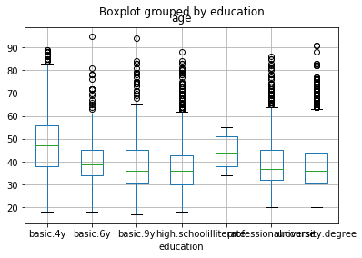

```python
df.boxplot('age', by= 'education')
```

```python
mod = smf.ols('age ~ education', data=df).fit()
anova_table = sm.stats.anova_lm(mod, typ=2)
anova_table
```

|  | sum_sq | df | F | PR(>F) |
| --- | --- | --- | --- | --- |
| education | 2.123928e+05 | 6.0 | 354.573796 | 0.0 |
| Residual | 3.043065e+06 | 30481.0 | NaN | NaN |

```python
pair_t = mod.t_test_pairwise('education')
pair_t.result_frame
```

|  | coef | std err | t | P>\|t\| | Conf. Int. Low | Conf. Int. Upp. | pvalue-hs | reject-hs |
| --- | --- | --- | --- | --- | --- | --- | --- | --- |
| basic.6y-basic.4y | -7.710521 | 0.337376 | -22.854371 | 1.218471e-114 | -8.371793 | -7.049250 | 0.000000e+00 | True |
| basic.9y-basic.4y | -9.453235 | 0.255529 | -36.994754 | 4.280600e-293 | -9.954083 | -8.952388 | 0.000000e+00 | True |
| high.school-basic.4y | -10.405884 | 0.234339 | -44.405310 | 0.000000e+00 | -10.865198 | -9.946570 | 0.000000e+00 | True |
| illiterate-basic.4y | -3.473071 | 3.019576 | -1.150185 | 2.500767e-01 | -9.391566 | 2.445424 | 4.376150e-01 | False |
| professional.course-basic.4y | -8.412774 | 0.255053 | -32.984432 | 1.816088e-234 | -8.912688 | -7.912859 | 0.000000e+00 | True |
| university.degree-basic.4y | -9.420885 | 0.227015 | -41.498943 | 0.000000e+00 | -9.865844 | -8.975926 | 0.000000e+00 | True |
| basic.9y-basic.6y | -1.742714 | 0.308582 | -5.647486 | 1.642591e-08 | -2.347548 | -1.137880 | 1.971109e-07 | True |
| high.school-basic.6y | -2.695363 | 0.291277 | -9.253593 | 2.308216e-20 | -3.266279 | -2.124447 | 0.000000e+00 | True |
| illiterate-basic.6y | 4.237450 | 3.024528 | 1.401029 | 1.612156e-01 | -1.690750 | 10.165651 | 4.098656e-01 | False |
| professional.course-basic.6y | -0.702252 | 0.308188 | -2.278649 | 2.269482e-02 | -1.306314 | -0.098191 | 1.594399e-01 | False |
| university.degree-basic.6y | -1.710364 | 0.285419 | -5.992475 | 2.089880e-09 | -2.269796 | -1.150931 | 2.716844e-08 | True |
| high.school-basic.9y | -0.952649 | 0.190565 | -4.999080 | 5.792344e-07 | -1.326164 | -0.579134 | 5.792329e-06 | True |
| illiterate-basic.9y | 5.980164 | 3.016495 | 1.982488 | 4.743361e-02 | 0.067709 | 11.892619 | 2.529124e-01 | False |
| professional.course-basic.9y | 1.040462 | 0.215528 | 4.827503 | 1.389244e-06 | 0.618018 | 1.462905 | 1.250313e-05 | True |
| university.degree-basic.9y | 0.032350 | 0.181483 | 0.178256 | 8.585233e-01 | -0.323364 | 0.388065 | 8.585233e-01 | False |
| illiterate-high.school | 6.932813 | 3.014773 | 2.299613 | 2.147686e-02 | 1.023731 | 12.841895 | 1.594399e-01 | False |
| professional.course-high.school | 1.993110 | 0.189926 | 10.494154 | 1.016663e-25 | 1.620848 | 2.365373 | 0.000000e+00 | True |
| university.degree-high.school | 0.984999 | 0.150185 | 6.558552 | 5.520139e-11 | 0.690629 | 1.279369 | 7.728196e-10 | True |
| professional.course-illiterate | -4.939703 | 3.016454 | -1.637586 | 1.015185e-01 | -10.852079 | 0.972674 | 3.483166e-01 | False |
| university.degree-illiterate | -5.947814 | 3.014213 | -1.973256 | 4.847543e-02 | -11.855797 | -0.039830 | 2.529124e-01 | False |
| university.degree-professional.course | -1.008111 | 0.180812 | -5.575465 | 2.489582e-08 | -1.362510 | -0.653712 | 2.738540e-07 | True |

### Results

As the above tables show, there is a very distinct statistical difference between the data from the varying groups. The first ANOVA test, which tested the model as a whole, came back with a p-value of less than .01, meaning that there was a statistical difference even at a 99% confidence level. Running the test on each individual grouping for Education came back showing that thirteen out of the twenty one relationships, or 62% of them, were statistically different from the others.

## K-Nearest Neighbors

Let's a new candidate came in the ways of a 45-year-old man withno housing loan. Would they be expected to accept the bank's offer?

```python
X = pd.DataFrame(data = df ,columns = ['age', 'Yhousing'])
X = X[['age', 'Yhousing']]
y= df['accepted']
X_train, X_test, y_train, y_test = train_test_split(X, y, random_state=1)
```

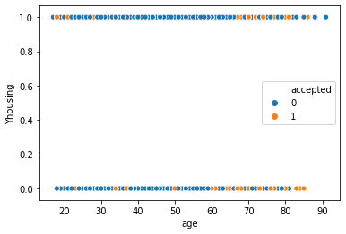

```python
X_train, X_test, y_train, y_test = train_test_split(X, y, random_state=1)
knn = KNeighborsClassifier(n_neighbors=5, metric='euclidean')
knn.fit(X_train, y_train)
y_pred = knn.predict(X_test)
sns.scatterplot(
    x='age',
    y='Yhousing',
    hue='accepted',
    data=X_test.join(y_test, how='outer'))
```

```python
confusion_matrix(y_test, y_pred)
```

```
array([[6552,   99],
       [ 925,   46]], dtype=int64)
```

```python
x2 = [[45, 0]]
pred = knn.predict(x2)
print("X=%s, Predicted=%s" % (x2[0], pred[0]))
```

```
X=[45, 0], Predicted=0
```

### Results

As for the new instance itself. If there is a 45-year-old person without a housing loan, they are not expected to accept the bank's offer.

## Building a Classification Tree Model

Another new person is added to the marketing data. This time it is a 50 year-old woman who has never defaulted, has a housing loan, but does not have a regular loan.

```python
X = pd.DataFrame(data = df, columns = ['age', 'Yhousing', 'Ydefault', 'Yloan'])
y= df['accepted']
X_train, X_test, y_train, y_test = train_test_split(X, y, random_state=0)
#Splitting the data set for prediction and setting up variables.
```

```python
clf = DecisionTreeClassifier(max_depth = 1, random_state = 0)
clf.fit(X_train, y_train)
```

```
DecisionTreeClassifier(class_weight=None, criterion='gini', max_depth=1,
                       max_features=None, max_leaf_nodes=None,
                       min_impurity_decrease=0.0, min_impurity_split=None,
                       min_samples_leaf=1, min_samples_split=2,
                       min_weight_fraction_leaf=0.0, presort=False,
                       random_state=0, splitter='best')
```

```python
#Testing accuracy of model.
score = clf.score(X_test, y_test)
score
```

```
0.874048806087641
```

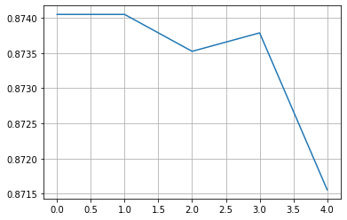

```python
#Creating function to test out other possible maximum depths of the model and their accuracy
max_depth_range = list(range(1, 6))
accuracy = []
for depth in max_depth_range:

    clf = DecisionTreeClassifier(max_depth = depth,random_state = 0)
    clf.fit(X_train, y_train)
    score = clf.score(X_test, y_test)
    accuracy.append(score)
plt.grid(True)
plt.plot(accuracy)
```

```python
accuracy
```

```
[0.874048806087641,
 0.874048806087641,
 0.8735240094463396,
 0.8737864077669902,
 0.871556022041459]
```

```python
importances = pd.DataFrame({'feature':X_train.columns,'importance':np.round(clf.feature_importances_,3)})
importances = importances.sort_values('importance',ascending=False)
importances
```

|  | feature | importance |
| --- | --- | --- |
| 0 | age | 0.973 |
| 1 | Yhousing | 0.014 |
| 3 | Yloan | 0.012 |
| 2 | Ydefault | 0.000 |

```python
x3 = [[50, 1, 0, 0]]
pred2 = clf.predict(x3)
print("X=%s, Predicted=%s" % (x3[0], pred2[0]))
```

```
X=[50, 1, 0, 0], Predicted=0
```

### Results

With an accuracy of 87%, this model is pretty effective at predicting the possibility of acceptance for a candidate if you know their age, whether they have a housing loan, whether they have a normal loan, and whether they have defaulted.

Of these factors, this model finds the candidate's age to be the most important, gives a little relevance to whether the candidate accepted a housing loan, and even less relevance to whether they have a normal loan. Whether they candidate defaulted or not has no relevance in the model and can be removed. This is probably because these variables are all highly correlated, so a vast majority of the information in the latter three variables are already given by a candidate's age.

So if a candidate is 50 years old and has a housing loan but not a normal loan and never defaulted, they are not expected to accept the bank's offer.

## Final Logistical Regression Testing Candidate Characteristics and Likelihood of Accepting Offer

```python
X= X.drop(['Ydefault'], axis=1)
X= sm.add_constant(X)
y= df['accepted']
logit1 = sm.Logit(y,X)
results = logit1.fit()
results.summary()
```

```
Optimization terminated successfully.
         Current function value: 432.821231
         Iterations 6
```

Logit Regression Results

| Dep. Variable: | accepted | No. Observations: | 30488 |
| --- | --- | --- | --- |
| Model: | Logit | Df Residuals: | 30484 |
| Method: | MLE | Df Model: | 3 |
| Date: | Thu, 17 Oct 2019 | Pseudo R-squ.: | inf |
| Time: | 02:15:41 | Log-Likelihood: | -1.3196e+07 |
| converged: | True | LL-Null: | 0.0000 |
| Covariance Type: | nonrobust | LLR p-value: | 1.000 |

|  | coef | std err | z | P>\|z\| | [0.025 | 0.975] |
| --- | --- | --- | --- | --- | --- | --- |
| const | -2.4922 | 0.069 | -36.029 | 0.000 | -2.628 | -2.357 |
| age | 0.0135 | 0.002 | 8.471 | 0.000 | 0.010 | 0.017 |
| Yhousing | 0.0610 | 0.035 | 1.757 | 0.079 | -0.007 | 0.129 |
| Yloan | -0.0418 | 0.048 | -0.869 | 0.385 | -0.136 | 0.052 |

```python
X= df[['age'] +['Yhousing']]
X=sm.add_constant(X)
logit1 = sm.Logit(y,X)
results = logit1.fit()
results.summary()
```

```
Optimization terminated successfully.
         Current function value: 432.795705
         Iterations 6
```

Logit Regression Results

| Dep. Variable: | accepted | No. Observations: | 30488 |
| --- | --- | --- | --- |
| Model: | Logit | Df Residuals: | 30485 |
| Method: | MLE | Df Model: | 2 |
| Date: | Thu, 17 Oct 2019 | Pseudo R-squ.: | inf |
| Time: | 02:15:41 | Log-Likelihood: | -1.3195e+07 |
| converged: | True | LL-Null: | 0.0000 |
| Covariance Type: | nonrobust | LLR p-value: | 1.000 |

|  | coef | std err | z | P>\|z\| | [0.025 | 0.975] |
| --- | --- | --- | --- | --- | --- | --- |
| const | -2.4984 | 0.069 | -36.313 | 0.000 | -2.633 | -2.364 |
| age | 0.0135 | 0.002 | 8.481 | 0.000 | 0.010 | 0.017 |
| Yhousing | 0.0596 | 0.035 | 1.718 | 0.086 | -0.008 | 0.128 |

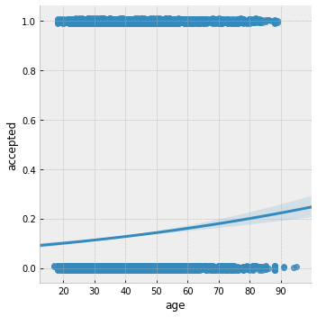

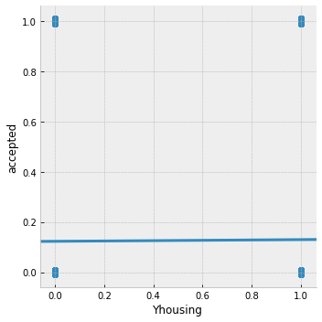

```python
plt.style.use('bmh')
sns.lmplot(x='age', y='accepted', data=df, logistic=True, y_jitter=.01)
sns.lmplot(x='Yhousing', y='accepted', data=df, logistic=True, y_jitter=.01)
```

```python
np.exp(results.params)
```

```
const       0.082214
age         1.013589
Yhousing    1.061400
dtype: float64
```

### Results

Of all the candidate characteristics, only a candidate's age and if they they had a housing loan were statistically significant at a 90% confidence level, and at a 95% confidence level the housing loan variable was dropped. That meant that at 95% confidence and above, only a candidate's age had any signicant relationship with their chance of accepting a loan.

Otherwise, the odds ratio shows that someone with a housing loan is 1.06 times as likely to accept the bank's offer than someone without, an interesting find, and every increase in someone's age by a single year increases their odds of accepting the bank's offer by 1.014 times as much.